# Summary of available time series

Benjamin Moran

2017-11-14

The data ranges from 2010 - 2017 but it is not an unbroken time series. The survey runs for about six months each year - usually beginning in May and ending in October - however the earlier years tend to have fewer surveys and each year does not span the same date range. The table below is a brief summary of this information.

# Summary Data

|  | Year | Number | FirstSurvey | LastSurvey |
| --- | --- | --- | --- | --- |
| 1 | 2010 | 14 | 2010-07-18 | 2010-10-17 |
| 2 | 2011 | 23 | 2011-05-08 | 2011-10-16 |
| 3 | 2012 | 23 | 2012-05-13 | 2012-10-14 |
| 4 | 2013 | 25 | 2013-05-05 | 2013-10-20 |
| 5 | 2014 | 24 | 2014-05-11 | 2014-10-19 |
| 6 | 2015 | 26 | 2015-04-26 | 2015-10-18 |
| 7 | 2016 | 25 | 2016-05-01 | 2016-10-16 |
| 8 | 2017 | 24 | 2017-04-30 | 2017-10-15 |

# Plots of Respondent Data

Here you can find a number of explanatory plots of the different time series available in the full data set.

## Total Respondents

Below is plot of the total number of respondents to the Flutracking survey for each week.

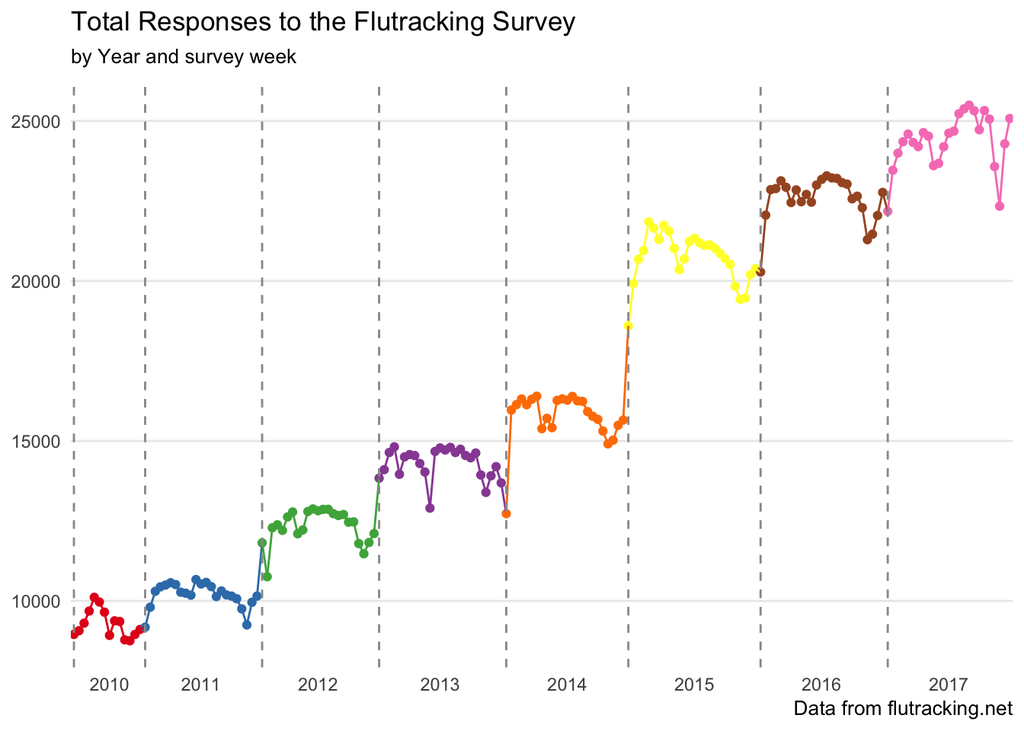

## Types of Responses

Survey participants can respond both for themselves (*Self*) and for other (*Other*) members of their household. The below plot breaks the total response data down into these groups.

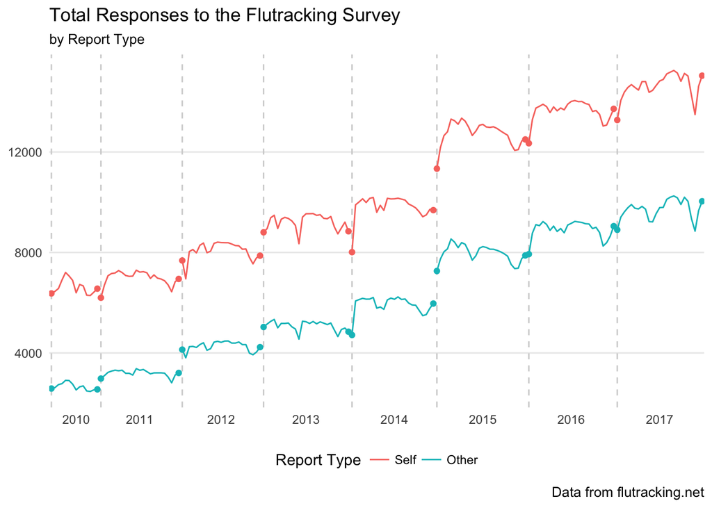

## Vaccination Status

Here the data is broken down into whether or not the subject of the survey (i.e. both self reports and others) has received the annual influenza vaccination. Note the spikes at the beginning of each year in the number of unvaccinated respondents due to the survey period beginning before some people have the chance to receive the vaccination.

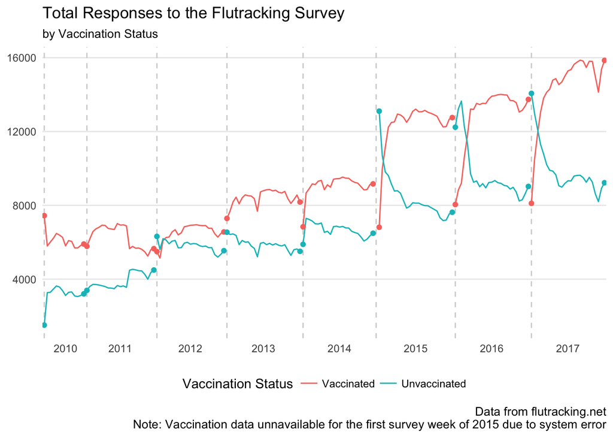

## Clinical Staff

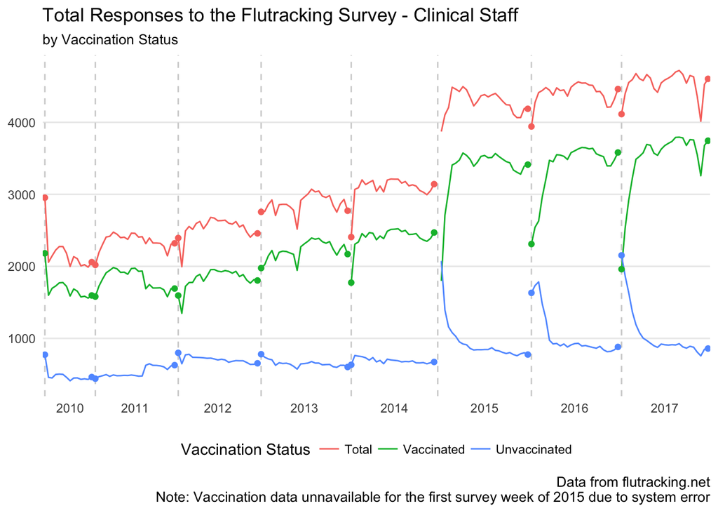

# Plots of Influenza-like-illness Symptoms Data

## % ILI Reported

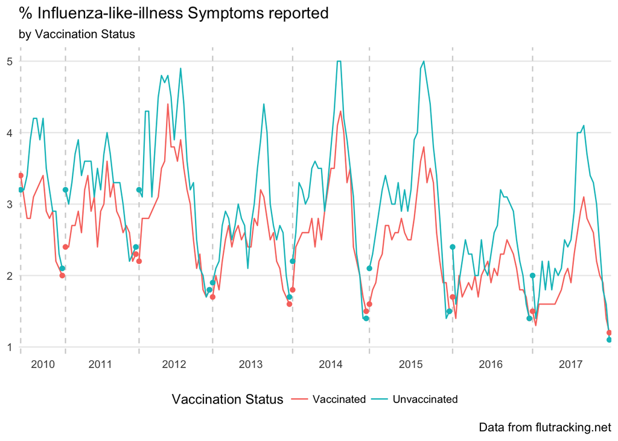

## % ILI Reported with Absence

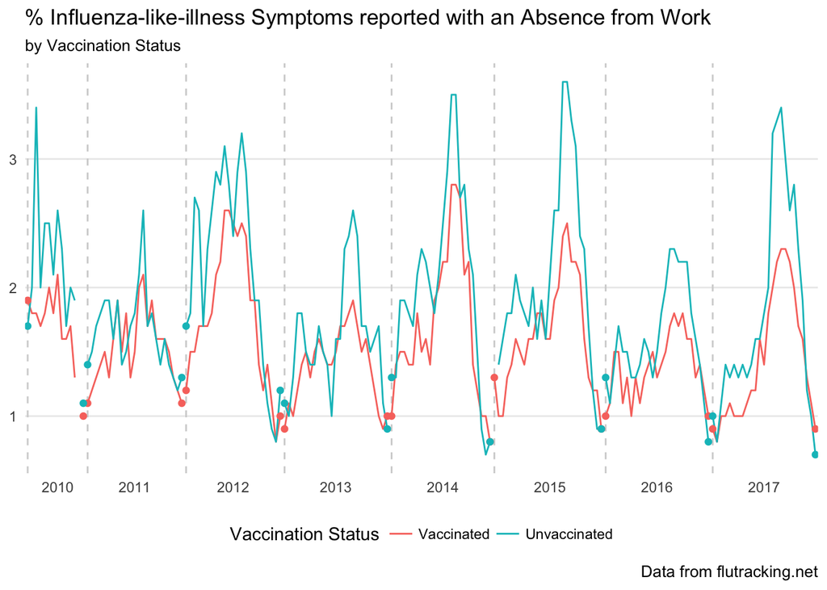